# Week 14, Lesson 25: Resampling technique

AG Schissler

Monday November 26, 2018

## I. Opening

### Start-of-class work

1. Log in the your workstation.
2. Open the RStudio application on your machine.
3. Open lesson25_resampling.Rmd from website so that you can work along the lecture.

### This week’s agenda

Digging into more computational methods of inference and computation, including

1. Jacknife
2. Bootstrap
3. Maximum Likelihood Estimation

## III. Bootstrap

Efron introduced the bootstrap in 1979. Since then there have been 1000+ theoretical papers assessing whether you can trust the boostrap. The answer is in most but not all cases the bootstrap works. It provides fully automatic inference (an algorithm). Rather than writing everything in math notation (since Efron and Hastie 2016 for clean way to do this), we’ll discuss the algorithm below.

### An R program for the nonparametric bootstrap

Modified from Efron and Hastie 2016, Algorithm 10.1.

```r
do_boot <- function(x, B, func, ...){
    ## x is a data vector or matrix (with each row a case)
    ## B is the number of bootstrap replicates
    ## func is a R function that inputs a data vector
    ## or matrix and returns a numeric number or vector
    ## ... other arguments for func
    x <- as.matrix(x)
    n <- nrow(x)
    f0 = func(x, ...) ## get size of output
    fmat <- matrix(0, length(f0), B)
    for (b in 1:B) {
        i = sample(1:n, n, replace = TRUE)
        fmat[, b] <- func(x[i, ], ...)
    }
    drop(fmat)
}
```

### Example from Rizzo 2006

```r
require(bootstrap)
str(law)
```

```
## 'data.frame':    15 obs. of  2 variables:
##  $ LSAT: num  576 635 558 578 666 580 555 661 651 605 ...
##  $ GPA : num  3.39 3.3 2.81 3.03 3.44 3.07 3 3.43 3.36 3.13 ...
```

```r
cor(law$LSAT, law$GPA)
```

```
## [1] 0.7763745
```

```r
## for all 82 schools
cor(law82$LSAT, law82$GPA)
```

```
## [1] 0.7599979
```

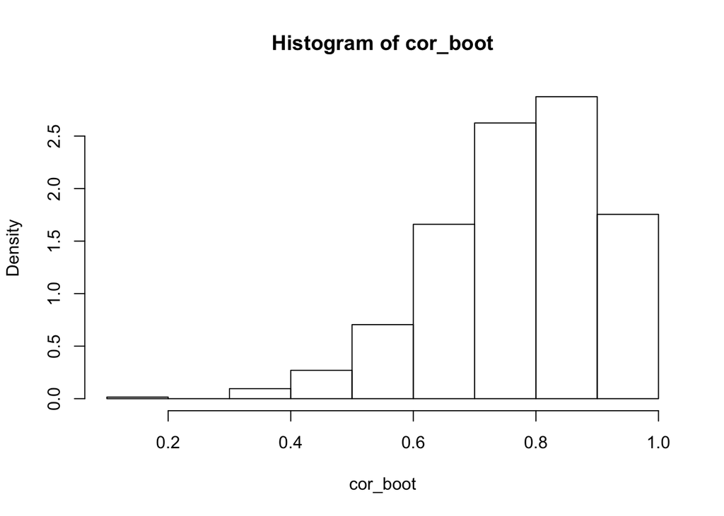

```r
set.seed(44)
cor_boot <- do_boot(x = law, B = 2000, func = cor)[2,]
hist(cor_boot, prob = TRUE)
```

```r
print(se_cor_boot <- sd(cor_boot))
```

```
## [1] 0.1327796
```

### The bootstrap estimation of bias

which can be estimated using the sample mean from the bootstrap samples minus the estimate of $\theta$ from the whole sample.

$$\hat{bias(\hat{\theta})} = \bar{\hat{\theta}^*} - \hat{\theta}$$

```r
## bias is
mean(cor_boot) - cor(law$LSAT, law$GPA)
```

```
## [1] -0.006206495
```

### Using the `boot` packge

```r
require(boot)
r <- function(x, i) {
    ## want correlation between columns 1 and 2
    cor(x[i,1], x[i,2])
}
boot_obj <- boot(data = law, statistic = r, R = 2000)
print(boot_obj)
```

```
##
## ORDINARY NONPARAMETRIC BOOTSTRAP
##
##
## Call:
## boot(data = law, statistic = r, R = 2000)
##
##
## Bootstrap Statistics :
##      original       bias    std. error
## t1* 0.7763745 -0.005859493   0.1316463
```

```r
str(boot_obj)
```

```
## List of 11
##  $ t0       : num 0.776
##  $ t        : num [1:2000, 1] 0.869 0.7 0.86 0.73 0.688 ...
##  $ R        : num 2000
##  $ data     :'data.frame':   15 obs. of  2 variables:
##   ..$ LSAT: num [1:15] 576 635 558 578 666 580 555 661 651 605 ...
##   ..$ GPA : num [1:15] 3.39 3.3 2.81 3.03 3.44 3.07 3 3.43 3.36 3.13 ...
##  $ seed     : int [1:626] 403 504 1623874101 1696795401 -1253537563 -402495787 -632699108 -1617879887 577861778 800984888 ...
##  $ statistic:function (x, i)
##   ..- attr(*, "srcref")= 'srcref' int [1:8] 2 6 5 1 6 1 2 5
##   .. ..- attr(*, "srcfile")=Classes 'srcfilecopy', 'srcfile' <environment: 0x7ff417fec238>
##  $ sim      : chr "ordinary"
##  $ call     : language boot(data = law, statistic = r, R = 2000)
##  $ stype    : chr "i"
##  $ strata   : num [1:15] 1 1 1 1 1 1 1 1 1 1 ...
##  $ weights  : num [1:15] 0.0667 0.0667 0.0667 0.0667 0.0667 ...
##  - attr(*, "class")= chr "boot"
##  - attr(*, "boot_type")= chr "boot"
```

### Bootstrap confidence intervals

```r
boot::boot.ci(boot.out = boot_obj, conf = 0.95)
```

```
## BOOTSTRAP CONFIDENCE INTERVAL CALCULATIONS
## Based on 2000 bootstrap replicates
##
## CALL :
## boot::boot.ci(boot.out = boot_obj, conf = 0.95)
##
## Intervals :
## Level      Normal              Basic
## 95%   ( 0.5242,  1.0403 )   ( 0.5903,  1.0846 )
##
## Level     Percentile            BCa
## 95%   ( 0.4682,  0.9625 )   ( 0.3350,  0.9425 )
## Calculations and Intervals on Original Scale
```

Note that BCa = “bias correct” and “adjusted for acceleration”.

## IV. Continue working on Lab 8, time permitting

## V. Summary

- Summarize the Jacknife procedure in 1-3 simple sentences.
- Summarize the Bookstrap procedure in 1-3 simple sentences.